# LDMV_IIParcial_Practico

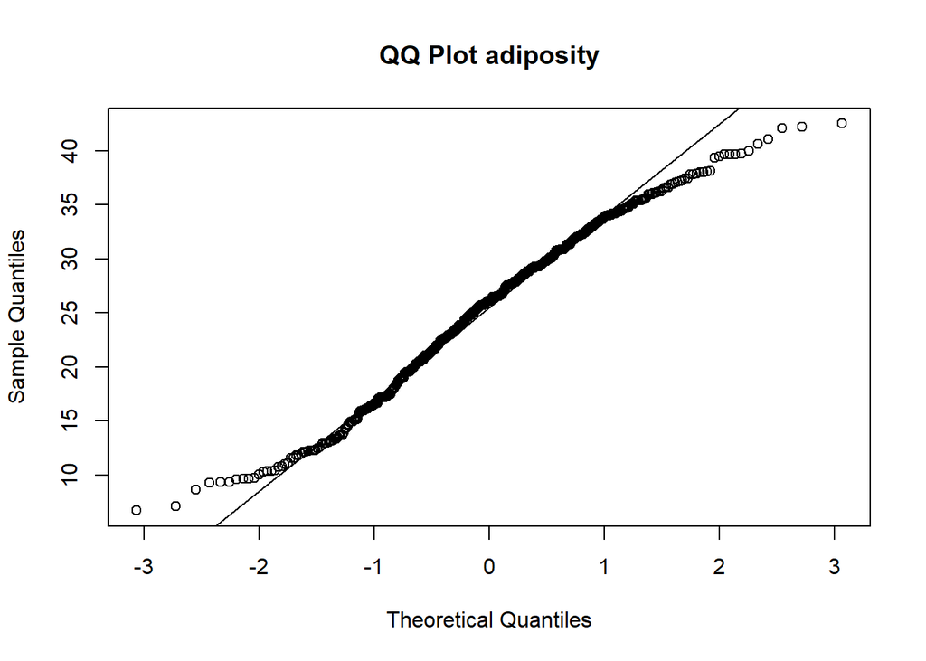

```r
qqnorm(datos$adiposity, main = "QQ Plot adiposity")
qqline(datos$adiposity)
```

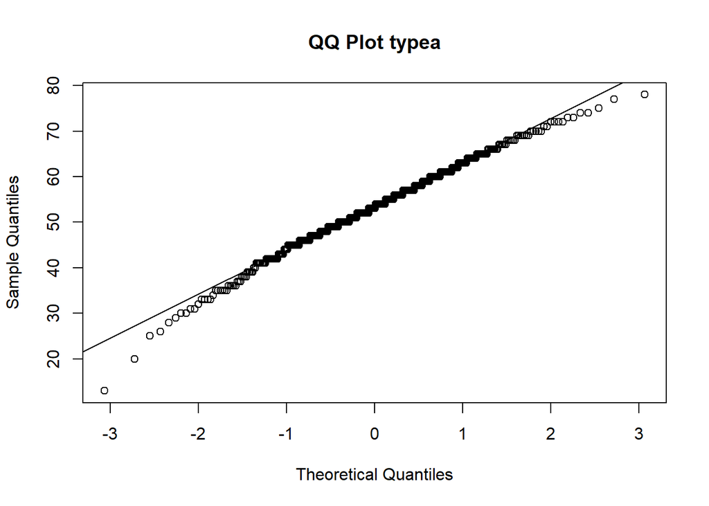

```r
qqnorm(datos$typea, main = "QQ Plot typea")
qqline(datos$typea)
```

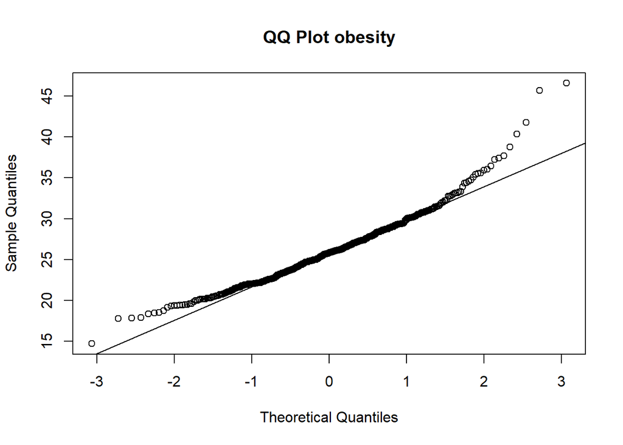

```r
qqnorm(datos$obesity, main = "QQ Plot obesity")
qqline(datos$obesity)
```

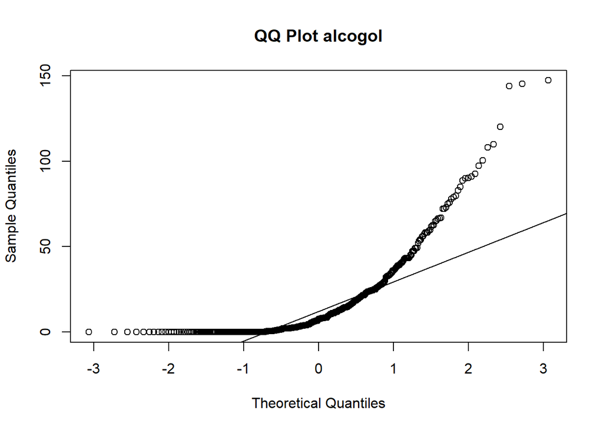

```r
qqnorm(datos$alcohol, main = "QQ Plot alcogol")
qqline(datos$alcohol)
```

#### Observaciones

En la mayoría de las variables los puntos no siguen completamente la línea del QQplot, lo que significa que los datos no son totalmente normales.

Algunas variables, como typea y obesity, se comportan un poco más estables, pero otras, como tobacco y alcohol, tienen valores muy dispersos.

Adicionalmente se observa que los valores no crean la linea en S que deberia de existir sobre el qqline

# Shapiro

En este test si el p-value < 0.05, significa que la variable no sigue una distribución normal.

```r
shapiro.test(datos$sbp)
```

```
##
##  Shapiro-Wilk normality test
##
## data:  datos$sbp
## W = 0.9231, p-value = 1.253e-14
```

```r
shapiro.test(datos$tobacco)
```

```
##
##  Shapiro-Wilk normality test
##
## data:  datos$tobacco
## W = 0.77372, p-value < 2.2e-16
```

```r
shapiro.test(datos$ldl)
```

```
##
##  Shapiro-Wilk normality test
##
## data:  datos$ldl
## W = 0.92075, p-value = 7.148e-15
```

```r
shapiro.test(datos$adiposity)
```

```
##
##  Shapiro-Wilk normality test
##
## data:  datos$adiposity
## W = 0.98353, p-value = 4.245e-05
```

```r
shapiro.test(datos$typea)
```

```
##
##  Shapiro-Wilk normality test
##
## data:  datos$typea
## W = 0.99137, p-value = 0.008604
```

```r
shapiro.test(datos$obesity)
```

```
##
##  Shapiro-Wilk normality test
##
## data:  datos$obesity
## W = 0.96074, p-value = 9.228e-10
```

```r
shapiro.test(datos$alcohol)
```

```
##
##  Shapiro-Wilk normality test
##
## data:  datos$alcohol
## W = 0.71435, p-value < 2.2e-16
```

```r
shapiro.test(datos$age)
```

```
##
##  Shapiro-Wilk normality test
##
## data:  datos$age
## W = 0.93705, p-value = 4.595e-13
```